# Executive Summary

## Executive Summary

Using devices such as Jawbone Up, Nike FuelBand, and Fitbit it is now possible to collect a large amount of data about personal activity relatively inexpensively. These type of devices are part of the quantified self movement - a group of enthusiasts who take measurements about themselves regularly to improve their health, to find patterns in their behavior, or because they are tech geeks. One thing that people regularly do is quantify how much of a particular activity they do, but they rarely quantify how well they do it. In this project, your goal will be to use data from accelerometers on the belt, forearm, arm, and dumbell of 6 participants. They were asked to perform barbell lifts correctly and incorrectly in 5 different ways. More information is available from the website here: http://groupware.les.inf.puc-rio.br/har (see the section on the Weight Lifting Exercise Dataset).

## Data

The training data for this project are available here: **https://d396qusza40orc.cloudfront.net/predmachlearn/pml-training.csv**

The test data are available here: **https://d396qusza40orc.cloudfront.net/predmachlearn/pml-testing.csv**

The data for this project come from this source: http://groupware.les.inf.puc-rio.br/har. If you use the document you create for this class for any purpose please cite them as they have been very generous in allowing their data to be used for this kind of assignment.

## What you should submit

The goal of your project is to predict the manner in which they did the exercise. This is the “classe” variable in the training set. You may use any of the other variables to predict with. You should create a report describing how you built your model, how you used cross validation, what you think the expected out of sample error is, and why you made the choices you did. You will also use your prediction model to predict 20 different test cases. Your submission should consist of a link to a Github repo with your R markdown and compiled HTML file describing your analysis. Please constrain the text of the writeup to < 2000 words and the number of figures to be less than 5. It will make it easier for the graders if you submit a repo with a gh-pages branch so the HTML page can be viewed online (and you always want to make it easy on graders :-). You should also apply your machine learning algorithm to the 20 test cases available in the test data above. Please submit your predictions in appropriate format to the programming assignment for automated grading. See the programming assignment for additional details.

## Reproducibility

Due to security concerns with the exchange of R code, your code will not be run during the evaluation by your classmates. Please be sure that if they download the repo, they will be able to view the compiled HTML version of your analysis.

### Loading libraries, and downloading the simulation data.

```r
library(ggplot2)
library(data.table)
library(caret)
library(randomForest)
library(rattle)
library(RColorBrewer)
library(rpart)
library(rpart.plot)
require(parallel)
require(doParallel)
url <- "http://d396qusza40orc.cloudfront.net/predmachlearn/pml-training.csv"
Data <- fread(url)

url <- "http://d396qusza40orc.cloudfront.net/predmachlearn/pml-testing.csv"
TestData <- fread(url)
```

**Model Build and selection below** **Our initial model includes all the data. We will shape our conclusion by using just the belt, arm, dumbbell, and forearm variables that are not missing values as our predictors.**

```r
isMissing <- sapply(TestData, function (x) any(is.na(x) | x == ""))
Prediction <- !isMissing & grepl("belt|[^(fore)]arm|dumbbell|forearm", names(isMissing))
isCandidate <- names(isMissing)[Prediction]
isCandidate
```

```
##  [1] "roll_belt"            "pitch_belt"           "yaw_belt"
##  [4] "total_accel_belt"     "gyros_belt_x"         "gyros_belt_y"
##  [7] "gyros_belt_z"         "accel_belt_x"         "accel_belt_y"
## [10] "accel_belt_z"         "magnet_belt_x"        "magnet_belt_y"
## [13] "magnet_belt_z"        "roll_arm"             "pitch_arm"
## [16] "yaw_arm"              "total_accel_arm"      "gyros_arm_x"
## [19] "gyros_arm_y"          "gyros_arm_z"          "accel_arm_x"
## [22] "accel_arm_y"          "accel_arm_z"          "magnet_arm_x"
## [25] "magnet_arm_y"         "magnet_arm_z"         "roll_dumbbell"
## [28] "pitch_dumbbell"       "yaw_dumbbell"         "total_accel_dumbbell"
## [31] "gyros_dumbbell_x"     "gyros_dumbbell_y"     "gyros_dumbbell_z"
## [34] "accel_dumbbell_x"     "accel_dumbbell_y"     "accel_dumbbell_z"
## [37] "magnet_dumbbell_x"    "magnet_dumbbell_y"    "magnet_dumbbell_z"
## [40] "roll_forearm"         "pitch_forearm"        "yaw_forearm"
## [43] "total_accel_forearm"  "gyros_forearm_x"      "gyros_forearm_y"
## [46] "gyros_forearm_z"      "accel_forearm_x"      "accel_forearm_y"
## [49] "accel_forearm_z"      "magnet_forearm_x"     "magnet_forearm_y"
## [52] "magnet_forearm_z"
```

**Subsetting the data to only include the predictors.**

```r
isIncluded <- c("classe", isCandidate)
Data <- Data[, isIncluded, with=FALSE]
dim(Data)
```

```
## [1] 19622    53
```

**Making classe into a factor**

```r
Data <- Data[, classe := factor(Data[, classe])]
Data[, .N, classe]
```

```
##    classe    N
## 1:      A 5580
## 2:      B 3797
## 3:      C 3422
## 4:      D 3216
## 5:      E 3607
```

### Next, we split our data 60% training and 40% for testing. We also do some partitioning, scaling and some verification.

```r
set.seed(1500)
inTrain <- createDataPartition(Data$classe, p=0.6)
DataTrain <- Data[inTrain[[1]]]
DataTest <- Data[-inTrain[[1]]]
```

#### Pre-process the data via centering and scaling.

```r
X <- DataTrain[, isCandidate, with=FALSE]
procData <- preProcess(X)
procData
```

```
##
## Call:
## preProcess.default(x = X)
##
## Created from 11776 samples and 52 variables
## Pre-processing: centered, scaled
```

```r
Z <- predict(procData, X)
DataTrainCS <- data.table(data.frame(classe = DataTrain[, classe], Z))
```

#### Center and Scale the test data

```r
var <- DataTest[, isCandidate, with=FALSE]
Z <- predict(procData, var)
DataTestCS <- data.table(data.frame(classe = DataTest[, classe], Z))
```

#### Examine for near-zero variables.

```r
nzv <- nearZeroVar(DataTrainCS, saveMetrics=TRUE)
if (any(nzv$nzv)) nzv else message("Data is clean")
```

```
## Data is clean
```

### Training our models for comparison against each other to determine the best fit for prediction.

#### We will be defining two seperate models in order to compare the accuracy and to help us better understand the data and ensure we have confidence in our predictions.

### First, let's examine the results using a decision tree

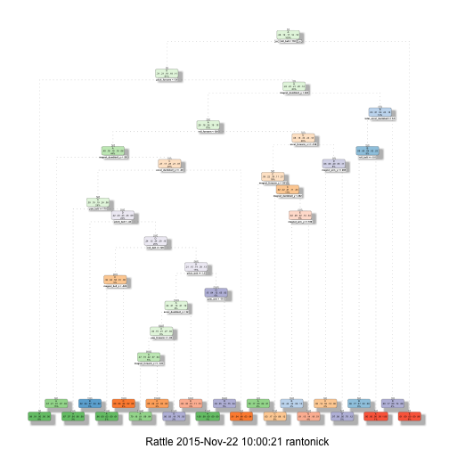

```r
model1 <- rpart( classe ~ .,  data=DataTrain, method="class" )
fancyRpartPlot( model1 )
```

#### Below we examine the Prediction which shows us an accuracy rate of only ~ 75%. Not bad, but there is room for improvement. Let's attempt the prediction with our second model.

```r
predictions1 <- predict( model1, DataTrain, type = "class" )
confusionMatrix( predictions1, DataTrain$classe )
```

```
## Confusion Matrix and Statistics
##
##           Reference
## Prediction    A    B    C    D    E
##          A 3120  491   32  195   66
##          B   69 1141  222   74  141
##          C   84  291 1572  157  176
##          D   51  152  154 1370  139
##          E   24  204   74  134 1643
##
## Overall Statistics
##
##                Accuracy : 0.7512
##                  95% CI : (0.7433, 0.759)
##     No Information Rate : 0.2843
##     P-Value [Acc > NIR] : < 2.2e-16
##
##                   Kappa : 0.6836
##  Mcnemar's Test P-Value : < 2.2e-16
##
## Statistics by Class:
##
##                      Class: A Class: B Class: C Class: D Class: E
## Sensitivity            0.9319  0.50066   0.7653   0.7098   0.7589
## Specificity            0.9070  0.94672   0.9272   0.9496   0.9546
## Pos Pred Value         0.7992  0.69277   0.6895   0.7342   0.7903
## Neg Pred Value         0.9710  0.88765   0.9492   0.9435   0.9462
## Prevalence             0.2843  0.19353   0.1744   0.1639   0.1838
## Detection Rate         0.2649  0.09689   0.1335   0.1163   0.1395
## Detection Prevalence   0.3315  0.13986   0.1936   0.1585   0.1765
## Balanced Accuracy      0.9194  0.72369   0.8463   0.8297   0.8568
```

```r
outOfSampleError <- 1 - as.numeric(confusionMatrix(DataTrain$classe, predictions1)$overall[1])
outOfSampleError
```

```
## [1] 0.2488111
```

```r
model2 <- randomForest( classe ~. , data=DataTrain)
predictions2 <- predict( model2, DataTrain, type = "class" )
confusionMatrix( predictions2, DataTrain$classe )
```

```
## Confusion Matrix and Statistics
##
##           Reference
## Prediction    A    B    C    D    E
##          A 3348    0    0    0    0
##          B    0 2279    0    0    0
##          C    0    0 2054    0    0
##          D    0    0    0 1930    0
##          E    0    0    0    0 2165
##
## Overall Statistics
##
##                Accuracy : 1
##                  95% CI : (0.9997, 1)
##     No Information Rate : 0.2843
##     P-Value [Acc > NIR] : < 2.2e-16
##
##                   Kappa : 1
##  Mcnemar's Test P-Value : NA
##
## Statistics by Class:
##
##                      Class: A Class: B Class: C Class: D Class: E
## Sensitivity            1.0000   1.0000   1.0000   1.0000   1.0000
## Specificity            1.0000   1.0000   1.0000   1.0000   1.0000
## Pos Pred Value         1.0000   1.0000   1.0000   1.0000   1.0000
## Neg Pred Value         1.0000   1.0000   1.0000   1.0000   1.0000
## Prevalence             0.2843   0.1935   0.1744   0.1639   0.1838
## Detection Rate         0.2843   0.1935   0.1744   0.1639   0.1838
## Detection Prevalence   0.2843   0.1935   0.1744   0.1639   0.1838
## Balanced Accuracy      1.0000   1.0000   1.0000   1.0000   1.0000
```

```r
outOfSampleError <- 1 - as.numeric(confusionMatrix(DataTrain$classe, predictions2)$overall[1])
outOfSampleError
```

```
## [1] 0
```

```r
train <- randomForest(DataTrain$classe ~.,data = DataTrain,importance = TRUE)
train_prediction<-predict(train,TestData)
hat <- train_prediction
TestData <- cbind(hat , TestData)
subset(TestData, select=names(TestData)[grep("belt|[^(fore)]arm|dumbbell|forearm", names(TestData), invert=TRUE)])
```

```
##     hat V1 user_name raw_timestamp_part_1 raw_timestamp_part_2
##  1:   B  1     pedro           1323095002               868349
##  2:   A  2    jeremy           1322673067               778725
##  3:   B  3    jeremy           1322673075               342967
##  4:   A  4    adelmo           1322832789               560311
##  5:   A  5    eurico           1322489635               814776
##  6:   E  6    jeremy           1322673149               510661
##  7:   D  7    jeremy           1322673128               766645
##  8:   B  8    jeremy           1322673076                54671
##  9:   A  9  carlitos           1323084240               916313
## 10:   A 10   charles           1322837822               384285
## 11:   B 11  carlitos           1323084277                36553
## 12:   C 12    jeremy           1322673101               442731
## 13:   B 13    eurico           1322489661               298656
## 14:   A 14    jeremy           1322673043               178652
```

[output cut: 27 more lines]